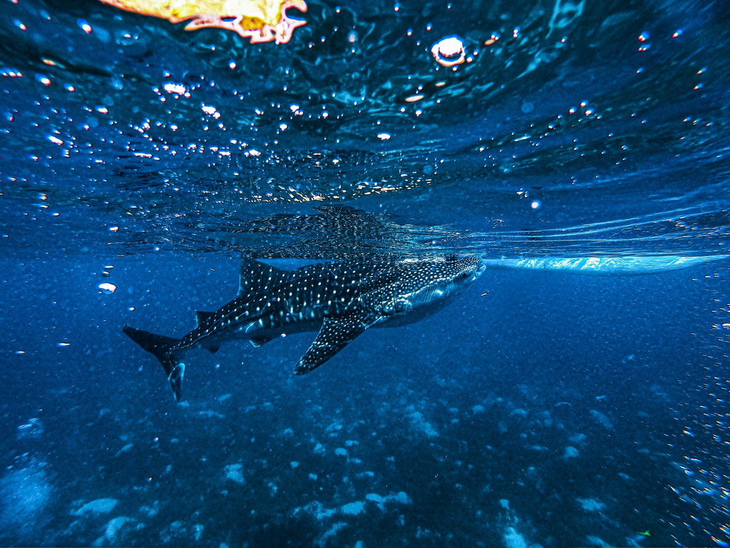

Ecological & Conservation Context

# Whale Shark Ecology & Conservation in the Coral Sea

Understanding how the world's largest fish uses tropical reef corridors, why satellite tags show surface bursts and deep-water gaps, and why international protection matters.

## 1. Filter-Feeding Giants in a Tropical Ocean

As the world's largest living fish (*Rhincodon typus*), whale sharks are ectothermic (cold-blooded) filter feeders that navigate warm tropical and subtropical seas in search of dense prey patches:

- **Spawning Aggregation Hotspots:** During late spring and austral summer (November–February), whale sharks gather along outer reefs of the northern Great Barrier Reef and Coral Sea to feed on zooplankton blooms and mass fish and coral spawning events.
- **Surface Thermoregulation:** After diving into deep, cooler ocean layers to forage, whale sharks return to sun-warmed surface waters to warm their bodies — creating the exact windows when fin-mounted satellite tags break the surface and uplink GPS locations.

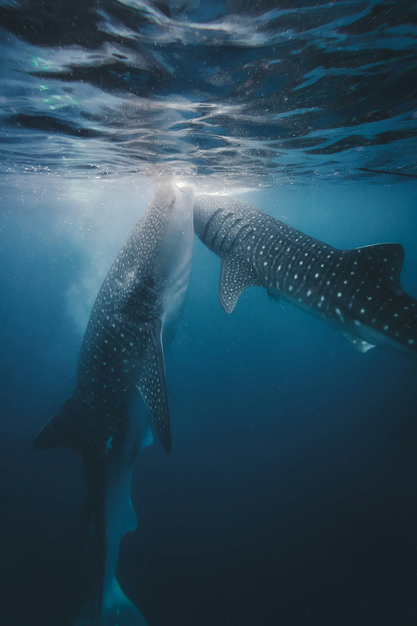

Surface feeding and basking windows allow fin-mounted tags to uplink GPS positions.

## 2. Cross-Border Ocean Roaming

- **From Reef Shelves to Deep Basins:** Tagged individuals travel across deep oceanic trenches between Queensland’s continental shelf, remote Coral Sea seamounts, and Papua New Guinea waters.
- **Subadult Male Dominance:** Like many coastal whale shark aggregations worldwide, a large share of the tagged Coral Sea individuals are immature and subadult sharks using productive shelf edges to fuel rapid growth before dispersing into the wider Indo-Pacific.

## 3. Why Satellite Telemetry Matters for Conservation

Whale sharks are listed as **Endangered** globally on the IUCN Red List due to vessel strikes, fisheries bycatch, and changing ocean temperatures:

- **Pinpointing High-Risk Shipping Lanes:** High-density tracking paths reveal where seasonal surface-feeding hotspots overlap with commercial shipping corridors along northeastern Australia and Papua New Guinea.
- **Protecting Connected Marine Parks:** Because individual sharks like *Megashark* and *Ali* roam across hundreds of kilometers over multiple years, effective conservation depends on linking Australia’s Great Barrier Reef and Coral Sea Marine Parks with neighboring Pacific protections.